# Using TrIdent

Jessie Maier

### Description:

TrIdent automates the transductomics data analysis process. Transductomics is a method developed by Dr. Manuel Kleiner to detect ongoing transduction in DNA sequencing reads. The method relies on mapping reads from a virome (VLP-fraction) of a sample to contigs assembled from the metagenome (whole-community) of the same sample. Reads from bacterial DNA carried by viruses or VLPs (Viral-Like Particles) will map back to their bacterial contigs of origin creating read coverage patterns indicative of active transduction. Read ‘Transductomics: sequencing-based detection and analysis of transduced DNA in pure cultures and microbial communities’ Kleiner et al. (2020) for more information.

**Reference:** Kleiner, M., Bushnell, B., Sanderson, K.E. et al. Transductomics: sequencing-based detection and analysis of transduced DNA in pure cultures and microbial communities. Microbiome 8, 158 (2020). https://doi.org/10.1186/s40168-020-00935-5

# TrIdent tutorial:

**TrIdent**- **Tr**ansduction **Ident**ification

TrIdent consists of three main functions to automatically detect, classify, and characterize potential transducing events:

- `TrIdent_Classifier()`: Classifies contigs as ‘Prophage-like’, ‘Gen/Lat/GTA’, ‘HighVLPWCReadCov’, and None
- `PlotTrIdentPatternMatches()`: Plots results of TrIdent_Classifier
- `SpecializedTransduction_ID()`: Detects potential specialized transduction on contigs classified as Prophage-like

Running TrIdent in default mode is the easiest, but users can learn how to use various arguments to modify TrIdent’s results in this tutorial.

##### Input Data:

The datasets used in this tutorial- ‘VLPFraction_sampledata’ and ‘WholeCommunity_sampledata’- were generated from a conventional mouse fecal metagenome. The homogenized feces represents the whole-community fraction. The VLP-fraction of the fecal sample was separated and purified via CsCl density gradient ultracentrifugation. Both the whole-community and VLP-fraction were shotgun sequenced after which the metagenome was assembled from the whole-community reads. The whole-community and VLP-fraction reads were mapped to the metagenome contigs and two pileup files were generated to summarize the respective read coverages across each contig. A description of this process is detailed in Kleiner et al. (2020). A subset of 10 contigs were selected for the sample dataset used in this tutorial.

The two pileup files were generated using BBMap’s `pileup.sh` with a binsize of 100. **We highly recommend using the commands below (with your own sorted .bam files) to generate the pileup files needed for TrIdent:**

```bash
pileup.sh in=VLPFraction_ReadMappingSorted.bam out=VLPFraction.pileupcovstats bincov=VLPFraction.bincov100 binsize=100 stdev=t

pileup.sh in=WholeCommunity_ReadMappingSorted.bam out=WholeCommunity.pileupcovstats bincov=WholeCommunity.bincov100 binsize=100 stdev=t
```

##### In R…

```r
library(TrIdent)
```

Import your pileup files:

The ‘VLPFraction.bincov100’ and ‘WholeCommunity.bincov100’ .txt files generated by BBMap’s `pileup.sh` can be used directly for input to TrIdent. **The windowsize/binsize used to generate these files must be 100**. Here is what the raw pileup file should look like however the information in the first column may be formatted differently depending on your contig accession format:

```
##                                           V1   V2  V3     V4
##  NODE_2 length_597362_cov_7.05514_ID_9556227 0.31 100 813702
##  NODE_2 length_597362_cov_7.05514_ID_9556227 0.44 200 813802
##  NODE_2 length_597362_cov_7.05514_ID_9556227 0.00 300 813902
##  NODE_2 length_597362_cov_7.05514_ID_9556227 0.00 400 814002
##  NODE_2 length_597362_cov_7.05514_ID_9556227 0.00 500 814102
##  NODE_2 length_597362_cov_7.05514_ID_9556227 0.00 600 814202
```

- The first column contains character strings of the contig accessions given by the assembler used.
- The second column contains numerical values of read coverages binned over 100 bp regions.
- The third column contains integer values for the starting position of each 100 bp bin. The position restarts at the start of each new contig.
- The fourth column contains integer values for the starting position of each 100 bp bin. The position does NOT restart at the start of each new contig.

TrIdent has built-in data cleaning and reformatting that is guaranteed to work for files output by BBMap’s `pileup.sh`. **If you do not use BBMap’s `pileup.sh` to generate the pileup files, then you are responsible for data-cleaning and reformatting.** Your pileup files must be in the following format (same column names, same column classes, etc.) and you must use the `cleanup=FALSE` argument for the `TrIdent_classifier()`, `Plot_TrIdentPatternMatches()`, and `SpecializedTransduction_ID()`.

```
##  ref_name coverage position
##    NODE_2     0.31      100
##    NODE_2     0.44      200
##    NODE_2     0.00      300
##    NODE_2     0.00      400
##    NODE_2     0.00      500
##    NODE_2     0.00      600
```

The `CleanVLPFraction_sampledata` comes preloaded with TrIdent. Feel free to use this dataframe as an example if you are doing your own data-cleaning and reformatting.

## Running TrIdent:

### TrIdent_Classifier():

`TrIdent_Classifier()` is the main function that TrIdent relies on. This function cleans and reformats your input data, filters contigs based on length and read coverage, performs pattern-matching to classify contigs, identifies active/highly abundant prophage/phage inducible chromosomal islands (PICIs), determines which contigs have high VLP-fraction:whole-community read coverage ratios, and outputs all information in a neat summary table.

`TrIdent_Classifier()` features:

1. **Contig filtering:**

   Contigs are filtered out based on short length or low read coverage. Contigs less than 30kbp and contigs where the 50th greatest coverage value is less than 10 are removed prior to pattern-matching. Contigs shorter than 30kbp are likely poor quality and are not big enough to show clear transduction patterns. **If you would like to speed-up processing time of TrIdent, consider pre-filtering your assembly for contigs greater than 30kbp!** Contigs where the 50th greatest coverage value is less than 10 means that there is no region on the contig with read coverages greater than 10 for at least 5,000bp. The low read coverage filtering was done in this way as to avoid filtering out long contigs with short Prophage-like patterns that might get removed if filtering was done with averages or medians. Complete Prophage-like patterns should be at least 10kbp, but we recognize that Prophage-like patterns that fall off the side of a contig may be shorter.
2. **Pattern-matching:**

   Contigs that are not filtered out proceed on to pattern-matching where they are matched a variety of patterns representing transduction events. Patterns are ‘built’ and scaled specific to the characteristics of each contig to ensure the best fits. After a pattern is built, it is translated across the contig being assessed, and the mean absolute difference (match-score) in coverage between the contig and the pattern is calculated at each translation. Theoretically, if a pattern is a perfect-match to the coverages on a contig, then taking the difference will result in a 0. Obviously, no pattern will be a *perfect*-match to a contig, but the closer to a 0 the match-score is, the better that pattern matches the read coverage pattern on the contig. The contig is classified based on the pattern that achieves the lowest match-score.

##### Patterns

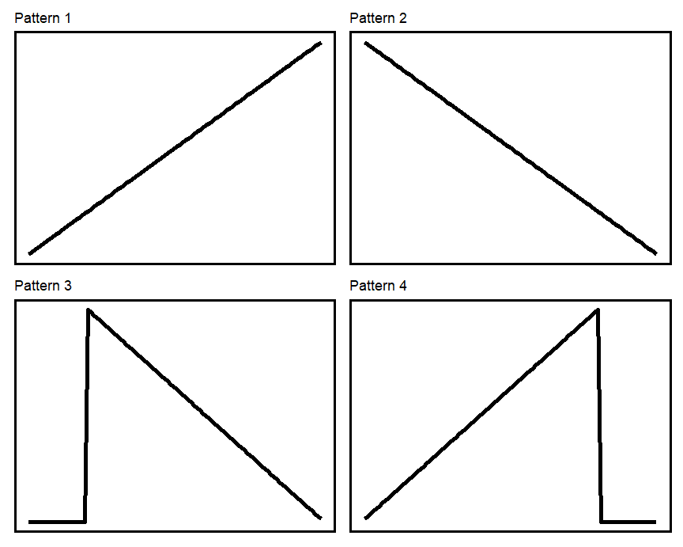

- **Prophage and PICIs (Prophage-like):**

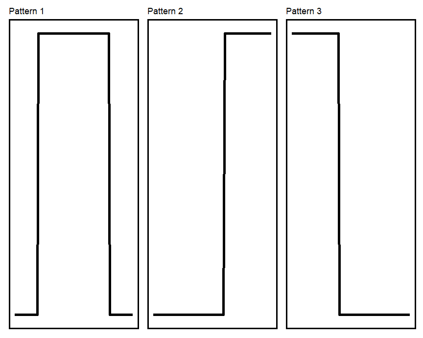

- **No transduction (None):**

There is one pattern in the None class. In order to know if the match score generated for a Gen/Lat/GTA or Prophage-like pattern match on a specific contig is ‘good’, we need a baseline match score to compare to. A contig without a Prophage-like or Gen/Lat/GTA pattern is likely to have fairly even read coverage across the contig which the None pattern tries to match. If the contig truely does have a Prophage-like or Gen/Lat/GTA pattern, its match score to the none score is likely to be worse than the match score to the pattern it truely matches. The pattern is built to the length of the contig being assessed and is simply the mean coverage of the contig.

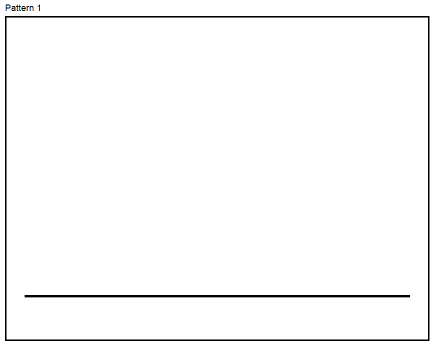

3. **Identifying highly active/abundant prophage/PICIs:**

   A prophage or PICI that is actively replicating or exists in high abundance in the environment will likely generate more reads than its respective host bacterium. This may create a region of elevated read coverage at the prophage/PICI insertion site in the whole-community fraction. This phenomenome has been previously studied by the Anantharaman lab and was used to produce their bioinformatics tool- PropagAtE. Since TrIdent locates prophage/PICIs as part of its pattern-matching, we can use the genomic coordinates to see if the associated prophage/PICI region has elevated read coverage in the whole-community fraction. Contigs where the prophage/PICI:non-prophage/PICI region has a mean read coverage ratio of greater than 1.3 are labeled highly active/abundant. If the non-prophage/PICI region is less than 20,000 bp, then the contig is labeled as ‘CBD’ (Can’t Be Determined) as its difficult to determine if the prophage/PICI region is truely elevated when there is so little non-prophage/PICI region to compare to.

   **Reference**: Kieft K, Anantharaman K. Deciphering Active Prophages from Metagenomes. mSystems. 2022 Apr 26;7(2):e0008422. doi: 10.1128/msystems.00084-22. Epub 2022 Mar 24. PMID: 35323045; PMCID: PMC9040807.
4. **Identifying contigs with high VLP-fraction:whole-community read coverages:**

`TrIdent_Classifier()` resizes the bins or ‘windows’ used by `pileup.sh` to improve processing time and reduce noise in the data. `TrIdent_Classifier()` resizes windows to 1000 bp as a default. Depending on the dataset, the user may want to select a different `windowsize`. Users can choose between windowsizes of 200, 500, 1000 or 2000 **only**. We recommend increasing the `windowsize` to 2000 if processing speed is of importance or if data is noisy (i.e. VLP-fraction contaminated with external bacterial DNA). We recommend decreasing the `windowsize` if your data is very clean and/or **small** and you are interested in increasing the resolution of read coverage patterns for the initial classification of contigs.

###### Default:

To run `TrIdent_Classifier()` in default-mode, run the following:

```r
TrIdent_results <- TrIdent_Classifier(VLPFraction_sampledata, WholeCommunity_sampledata)
## Starting pattern-matching...
## A quarter of the way done with pattern_matching
## Half of the way done with pattern_matching
## Almost done with pattern_matching!
## Identifying potential transducing events
## Determining sizes (bp) of potential transduction events
## Identifying highly active/abundant prophage-like elements
## Finalizing output
## Execuion time: 42.5243909358978
## 1 contigs were filtered out based on short length or low read coverage
##
##      Gen/Lat/GTA HighVLPWCReadCov             None    Prophage-like
##                2                2                1                4
## 3 of the predicted prophages are highly active or abundant
```

###### Non-default:

Increasing/decreasing the `windowsize` may alter the results of the `TrIdent_Classifier()` slightly. Prophage-like classifications tend to stay the same when `windowsize` is changed, but Gen/Lat/GTA and HighVLPWCReadCov classifications may switch classes with each other. This is due to how averaging the read coverages affects the sloping pattern. High activity/abundance labels on Prophage-like classifications may also change based on how the averaging affects the pattern-match size. Prophage/PICIs that are on the border of being considered highly active/abundant are typically more affected by changing the `windowsize`.

Note how processing time compares between the default of 1000 `windowsize` and the user-defined 2000 and 500 `windowsize`. The differences are small since the sample dataset only consists of 10 contigs, but on larger datasets these time differences can add up.

Increase `windowsize` to 2000bp:

```r
TrIdent_results_increasewindow <- TrIdent_Classifier(VLPFraction_sampledata, WholeCommunity_sampledata, windowsize=2000)
## Starting pattern-matching...
## A quarter of the way done with pattern_matching
## Half of the way done with pattern_matching
## Almost done with pattern_matching!
## Identifying potential transducing events
## Determining sizes (bp) of potential transduction events
## Identifying highly active/abundant prophage-like elements
## Finalizing output
## Execuion time: 26.4607710838318
## 1 contigs were filtered out based on short length or low read coverage
##
##      Gen/Lat/GTA HighVLPWCReadCov             None    Prophage-like
##                2                2                1                4
## 3 of the predicted prophages are highly active or abundant
```

Decrease `windowsize` to 500bp:

```r
TrIdent_results_increasewindow <- TrIdent_Classifier(VLPFraction_sampledata, WholeCommunity_sampledata, windowsize=500)
## Starting pattern-matching...
## A quarter of the way done with pattern_matching
## Half of the way done with pattern_matching
## Almost done with pattern_matching!
## Identifying potential transducing events
## Determining sizes (bp) of potential transduction events
## Identifying highly active/abundant prophage-like elements
## Finalizing output
## Execuion time: 48.4913930892944
## 1 contigs were filtered out based on short length or low read coverage
##
##      Gen/Lat/GTA HighVLPWCReadCov             None    Prophage-like
##                2                2                1                4
## 3 of the predicted prophages are highly active or abundant
```

##### Obtain results of main classifier:

The output of `TrIdent_Classifier()` is a list containing five objects:

1. Full_summary_table: A summary table containing the classification information for all contigs that were not filtered out.
2. Cleaned_summary_table: A cleaned summary table containing the classification information for all contigs classified as either Prophage-like or Gen/Lat/GTA (i.e. ’None classifications removed)
3. PatternMatchInfo: A list of pattern-match info that is used by other functions in TrIdent.
4. FilteredOutContig_table: A table of contigs that were filtered out and the reason why (either low read coverage or too short(<30kbp)).
5. Windowsize: The windowsize used.

Save the desired list-item to a new variable using its associated name:

```r
TrIdent_summary_table <- TrIdent_results$Full_summary_table
```

The TrIdent_Classifier output summary table

| ref_name | classifications | match_size | active_prophage |
| --- | --- | --- | --- |
| NODE_2 | Prophage-like | 8000 | YES |
| NODE_25 | None | NA | NA |
| NODE_44 | Prophage-like | 65000 | YES |
| NODE_62 | Prophage-like | 171000 | YES |
| NODE_125 | Prophage-like | 31000 | NO |
| NODE_238 | Gen/Lat/GTA | 146000 | NA |
| NODE_251 | Gen/Lat/GTA | 144000 | NA |
| NODE_560 | HighVLPWCReadCov | NA | NA |
| NODE_1088 | HighVLPWCReadCov | NA | NA |

```r
filteredout_contigs <- TrIdent_results$FilteredOutContig_table
```

The TrIdent_Classifier filtered-out contig summary table

| filteredout_contigs | reason |
| --- | --- |
| NODE_4 | Low VLP-fraction read cov |